# R Wykresy

## Histogramy

Histogramy (tworzone m.in. za pomoca funkcji `hist`, wykonującej wszystkie obliczenia) są graficznym obrazem tego, co w statystyce nazywane jest rozkładem z próby (*ang. sample distribution*).

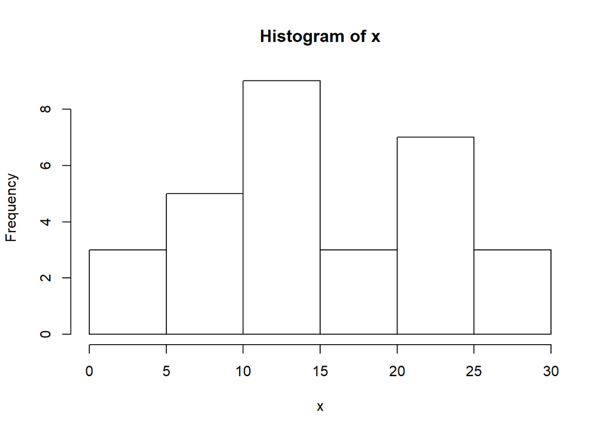

```r
x=c(18.03, 11.49, 18.49, 22.23, 12.96, 6.48, 11.58, 21.26, 24.64, 4.69, 29.73, 22.11, 2.00, 5.29, 23.60, 13.53, 27.66, 21.26, 11.66, 5.10, 11.70, 12.00, 23.35, 2.45, 16.12, 11.00, 11.96, 28.69, 7.11, 6.90)
hist(x)
```

Jeżeli N jest liczbą wszystkich danych, a N[x1,x2] liczbą danych należących do przedziału [x1,x2] to:

- $N[x1,x2]$ jest liczebnością przdziału
- $\frac{N[x1,x2]}{N}$ jest frakcją/prawdopodobieństwem przedziału
- $\frac{N[x1,x2]}{N}*100$ jest procentem jaki stanowi dany przedział
- $\frac{N[x1,x2]}{(x2-x1)}$ jest zagęszczeniem
- $\frac{N[x1,x2]}{N*(x2-x1)}$ jest intensywnością (gęstością) prawdopodobieństwa

Funkcja `hist` tworzy standardowo wykresy liczebności zagęszczeń danych i suma wysokości wykreślonych słupków jest równa liczbie wszystkich obiektów. Najlepszą interpretację w odniesieniu do rzeczywistości mają wykresy intensywności prawdopodobieństwa. Są one przybliżeniem prawdopodobieństwa z jakim możemy wylosować obiekt o danej wartości zmiennej z całej populacji. Wykres intensywności prawdopodobieństwa uzyskamy stosując jedną z opcji: freq=FALSE albo prob=TRUE. W tego typu wykresie suma pół powierzchni wykreślonych słupków jest równa 1.

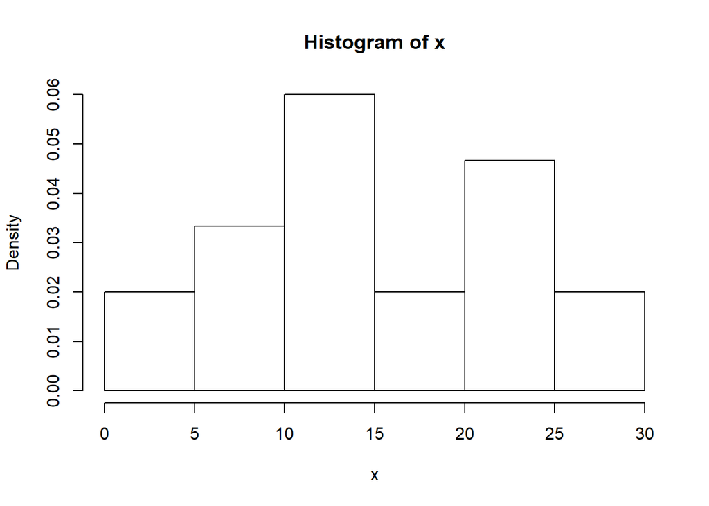

```r
x=c(18.03, 11.49, 18.49, 22.23, 12.96, 6.48, 11.58, 21.26, 24.64, 4.69, 29.73, 22.11, 2.00, 5.29, 23.60, 13.53, 27.66, 21.26, 11.66, 5.10, 11.70, 12.00, 23.35, 2.45, 16.12, 11.00, 11.96, 28.69, 7.11, 6.90)
hist(x, prob=TRUE)
```

### Podstawowe opcje nadrzędnych funkcji graficznych

Funkcje graficzne posiadają szereg opcji, które wpisuje się wewnątrz nawiasów okrągłych na zasadzie `opcja=...` Są one jednakowe dla wszystkich przedstawionych funkcji. Umożliwiają zatytułowanie wykresu, podpisanie osi, określenie kolorów i wzorów różnych elementów wykresu itp. Najberdziej potrzebne wydaja się opcje związane z utworzeniem tytułu wykresu i podpisów pod osiami (automatycznie generowana podpisy są najczęściej nie do zaakceptowania).

- `main=` - Tytuł wykresu napisany na górnym marginesie.
- `sub=` - Podpis wykresu napisany na dolnym marginesie.
- `xlab=` - Tytuł osi 0X napisany na dolnym marginesie.
- `ylab=` - Tytuł osi 0Y napisany na lewym marginesie.

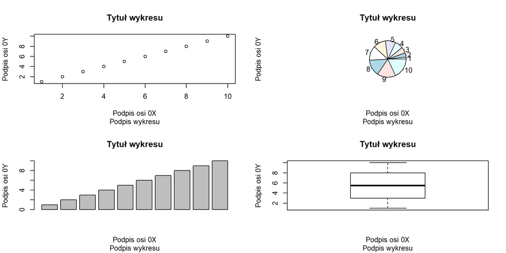

```r
par(mfrow=c(2,2))
plot(1:10, main="Tytuł wykresu",
    sub="Podpis wykresu",
    xlab="Podpis osi 0X",
    ylab="Podpis osi 0Y")

pie(1:10, main="Tytuł wykresu",
    sub="Podpis wykresu",
    xlab="Podpis osi 0X",
    ylab="Podpis osi 0Y")

barplot(1:10, main="Tytuł wykresu",
    sub="Podpis wykresu",
    xlab="Podpis osi 0X",
    ylab="Podpis osi 0Y")

boxplot(1:10, main="Tytuł wykresu",
    sub="Podpis wykresu",
    xlab="Podpis osi 0X",
    ylab="Podpis osi 0Y")
```

### Inne najczęściej stosowane opcje

- `adj=` - Sposób wyśrodkowania napisów i podpisów. 0 (z lewej), 0.5 (wyśrodkowane), 1 (do prawej). Może być dowolną liczbą z przedziału [0,1].
- `col.main=` - Kolor tytułu
- `col.sub=` - Kolor podpisu
- `col.lab=` - Kolor podpisów osi
- `col=` - Kolor elementów wykresu
- `ps=` - Wielkość czcionki.
- `xlim=c(a,b)` - Zakres zmienności danych na osi 0X (od liczby a do liczby b)
- `ylim=c(a,b)` - Zakres zmienności danych na osi 0Y (od liczby a do liczby b)
- `pch=` - Wzór znaczników dla punktów
- `cex=` - Wielkość znaczników
- `lty=` - Typ linii w wykresach liniowych, punktowo liniowych i schodkowych
- `lwd=` - Grubość linii w wykresach liniowych, punktowo liniowych i schodkowych
- `asp=x` - Jednostki na osi 0Y w stosunku do jednostek na osi 0X są równe x (dotyczy funkcji `plot`, `matplot`, `barplot`)

# Wykresy - funkcje bardziej zaawansowane

## Wykresy słupkowe

```r
# if(!require(devtools)) install.packages("ggpubr")
# if(!require(devtools)) install.packages("devtools")
# devtools::install_github("kassambara/ggpubr")

library(ggpubr)

df <- data.frame(dose=c("D0.5", "D1", "D2"),
                 len=c(4.2, 10, 29.5))
print(df)
```

```
##   dose  len
## 1 D0.5  4.2
## 2   D1 10.0
## 3   D2 29.5
```

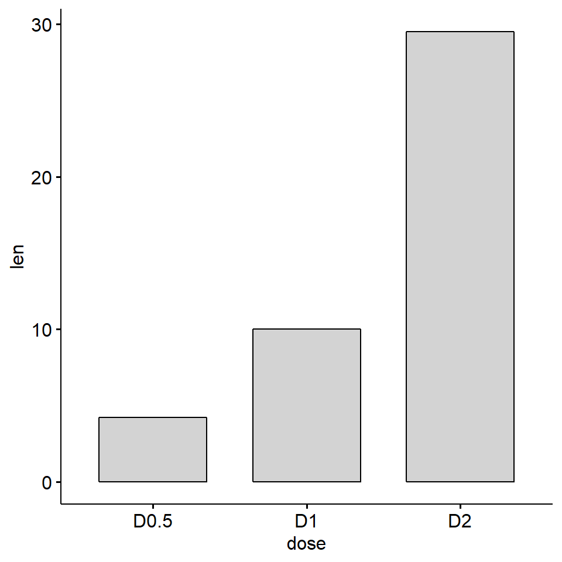

```r
# Basic bar plots with label
par(mfrow=c(1,2))
p <- ggbarplot(df, x = "dose", y = "len",
          color = "black", fill = "lightgray")
p
```

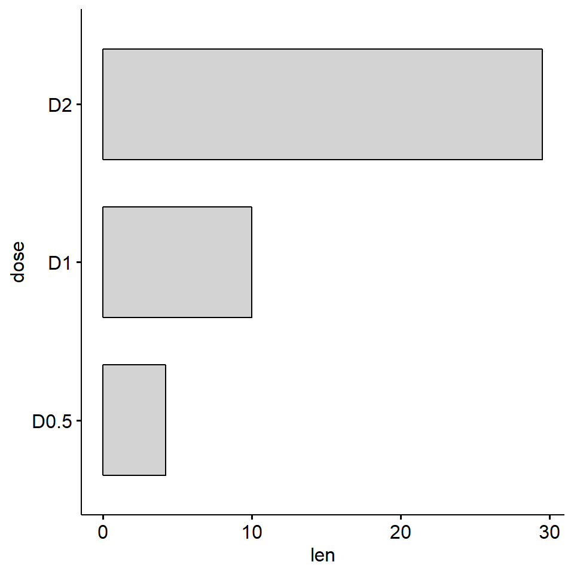

```r
# Rotate to create horizontal bar plots
p + rotate()
```

### Trochę koloru

Wykresy można i należy modyfikować zgodnie z własnymi potrzebami i gustem

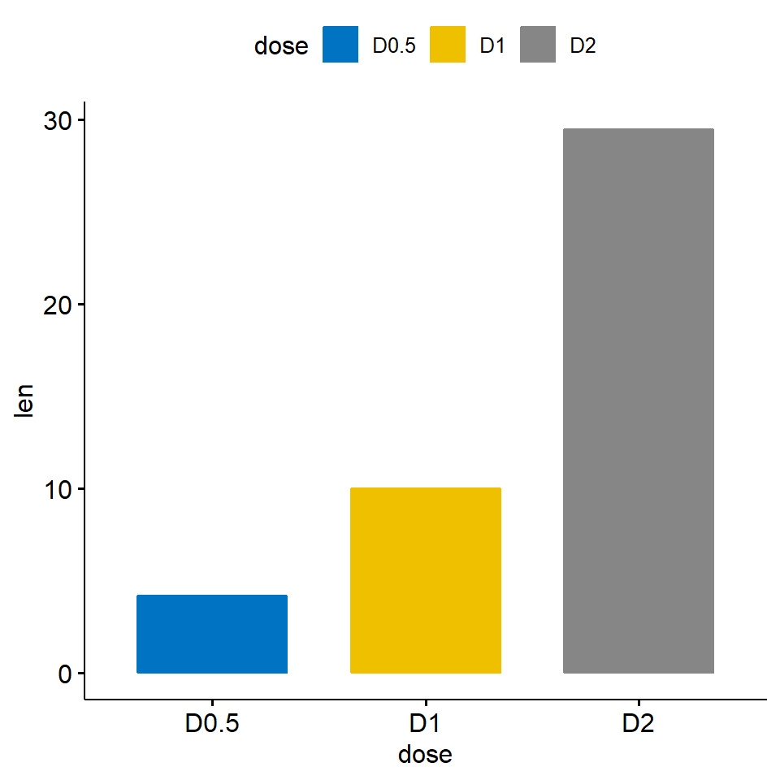

```r
ggbarplot(df, x = "dose", y = "len",
   fill = "dose", color = "dose", palette = "jco")
```

### Zmienne grupujące

Narysuj y = “len” z podziałem na x = “dose” i zastosuj różne kolory zależnie od zmiennej “supp”

```r
df2 <- data.frame(supp=rep(c("VC", "OJ"), each=3),
                  dose=rep(c("D0.5", "D1", "D2"),2),
                  len=c(6.8, 15, 33, 4.2, 10, 29.5))
print(df2)
```

```
##   supp dose  len
## 1   VC D0.5  6.8
## 2   VC   D1 15.0
## 3   VC   D2 33.0
## 4   OJ D0.5  4.2
## 5   OJ   D1 10.0
## 6   OJ   D2 29.5
```

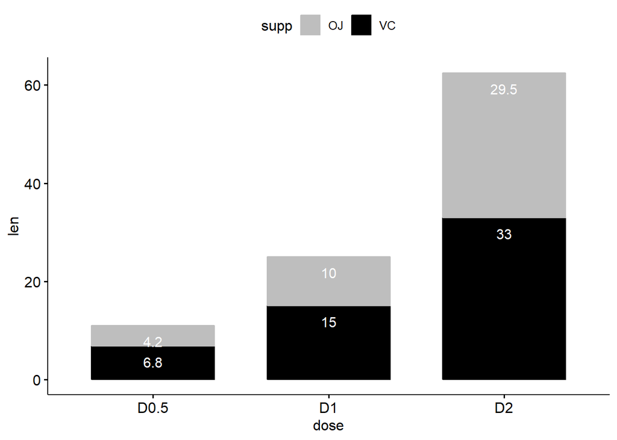

```r
# Wykres zgrupowany, etykiety wewnątrz
ggbarplot(df2, x = "dose", y = "len",
  fill = "supp", color = "supp",
  palette = c("gray", "black"),
  label = TRUE, lab.col = "white", lab.pos = "in")
```

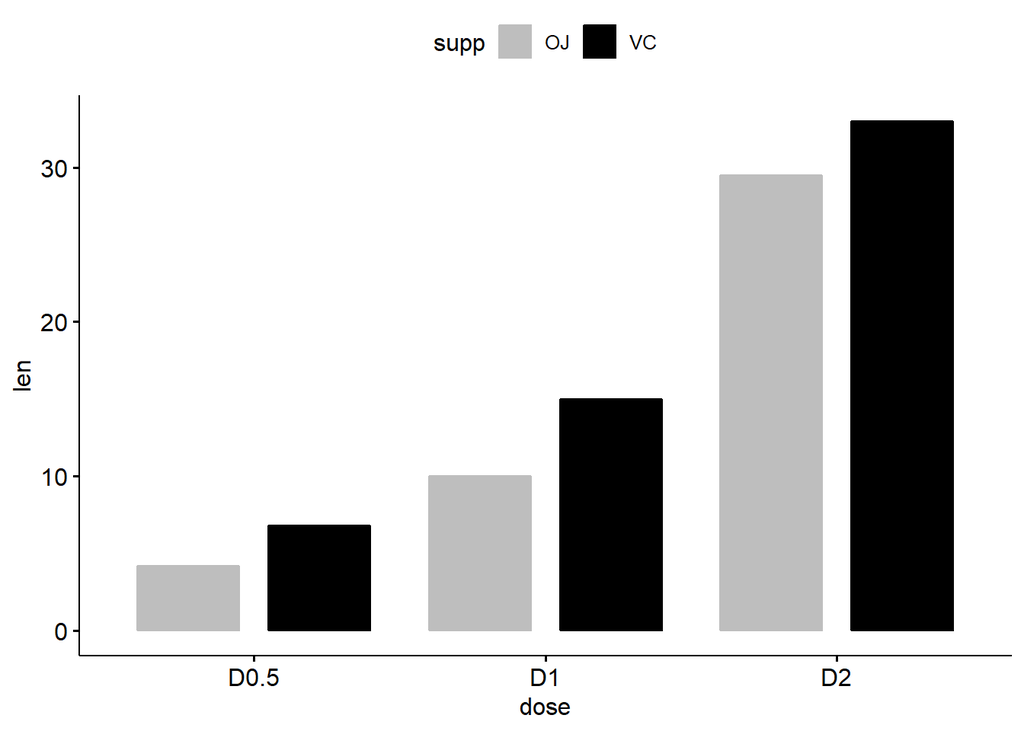

```r
# Słupki obok siebie
ggbarplot(df2, x = "dose", y = "len",
          fill = "supp", color = "supp",
          palette = c("gray", "black"),
          position = position_dodge(0.9))
```

### uporządkowane wykresy słupkowe

```r
# Wprowadzanie danych
data("mtcars")
dfm <- mtcars
# zamiana zmiennej cyl na czynniki
dfm$cyl <- as.factor(dfm$cyl)
# dodawanie nazw wierszom
dfm$name <- rownames(dfm)

head(dfm[, c("name", "wt", "mpg", "cyl")])
```

|  | name | wt | mpg | cyl |
| --- | --- | --- | --- | --- |
| Mazda RX4 | Mazda RX4 | 2.620 | 21.0 | 6 |
| Mazda RX4 Wag | Mazda RX4 Wag | 2.875 | 21.0 | 6 |
| Datsun 710 | Datsun 710 | 2.320 | 22.8 | 4 |
| Hornet 4 Drive | Hornet 4 Drive | 3.215 | 21.4 | 6 |
| Hornet Sportabout | Hornet Sportabout | 3.440 | 18.7 | 8 |
| Valiant | Valiant | 3.460 | 18.1 | 6 |

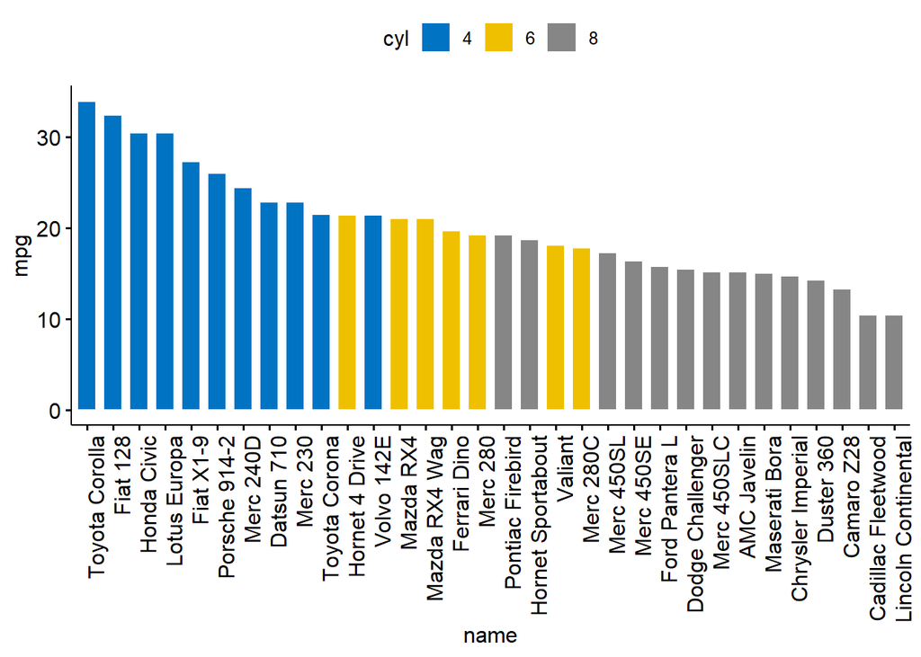

```r
ggbarplot(dfm, x = "name", y = "mpg",
          fill = "cyl",               # kolor zależny od zmiennej cyl
          color = "white",            # otoczki w białym kolorze
          palette = "jco",            # jco journal color palett. zobacz ?ggpar
          sort.val = "desc",          # sortowanie malejaco
          sort.by.groups = FALSE,     # nie sortuj wewnątrz grup
          x.text.angle = 90           # obróć tekst na osi x wertykalnie
          )
```

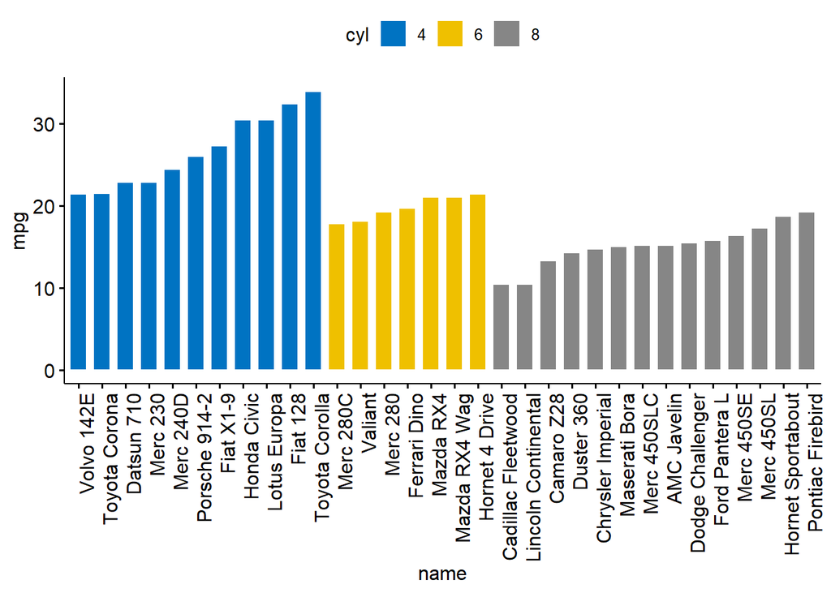

```r
ggbarplot(dfm, x = "name", y = "mpg",
          fill = "cyl",
          color = "white",
          palette = "jco",
          sort.val = "asc",
          sort.by.groups = TRUE,      # Posortuj wewnątrz grup
          x.text.angle = 90
          )
```

### Wykres odchyleń

Pokazuje odchylenie wartości od wartości referencyjnej.

```r
# oblicznie z-score (znormalizowany rozkład normalny) dla spalania
dfm$mpg_z <- (dfm$mpg -mean(dfm$mpg))/sd(dfm$mpg)
dfm$mpg_grp <- factor(ifelse(dfm$mpg_z < 0, "low", "high"),
                     levels = c("low", "high"))

head(dfm[, c("name", "wt", "mpg", "mpg_z", "mpg_grp", "cyl")])
```

|  | name | wt | mpg | mpg_z | mpg_grp | cyl |
| --- | --- | --- | --- | --- | --- | --- |
| Mazda RX4 | Mazda RX4 | 2.620 | 21.0 | 0.1508848 | high | 6 |
| Mazda RX4 Wag | Mazda RX4 Wag | 2.875 | 21.0 | 0.1508848 | high | 6 |
| Datsun 710 | Datsun 710 | 2.320 | 22.8 | 0.4495434 | high | 4 |
| Hornet 4 Drive | Hornet 4 Drive | 3.215 | 21.4 | 0.2172534 | high | 6 |
| Hornet Sportabout | Hornet Sportabout | 3.440 | 18.7 | -0.2307345 | low | 8 |
| Valiant | Valiant | 3.460 | 18.1 | -0.3302874 | low | 6 |

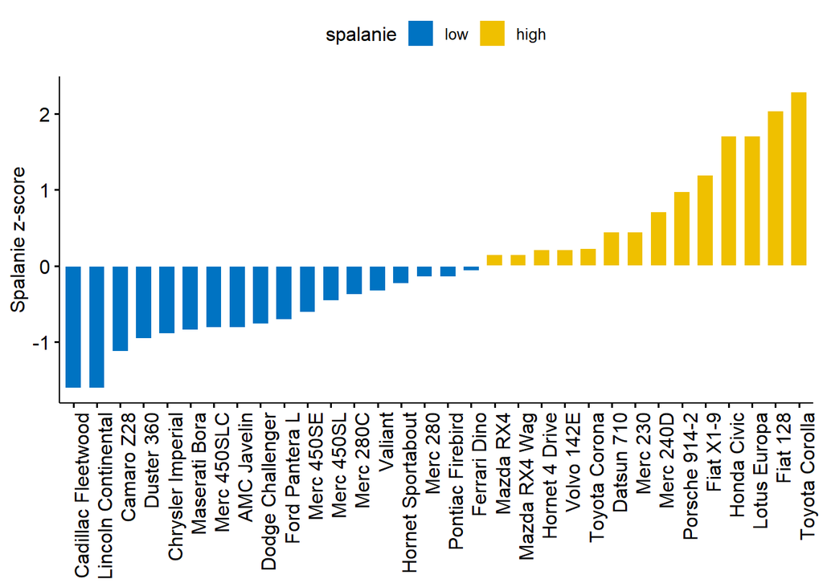

```r
ggbarplot(dfm, x = "name", y = "mpg_z",
          fill = "mpg_grp",           # kolor zależny od poziomu spalania
          color = "white",
          palette = "jco",
          sort.val = "asc",           # Posortuj rosnąco
          sort.by.groups = FALSE,
          x.text.angle = 90,
          ylab = "Spalanie z-score",
          xlab = FALSE,
          legend.title = "spalanie"
          )
```

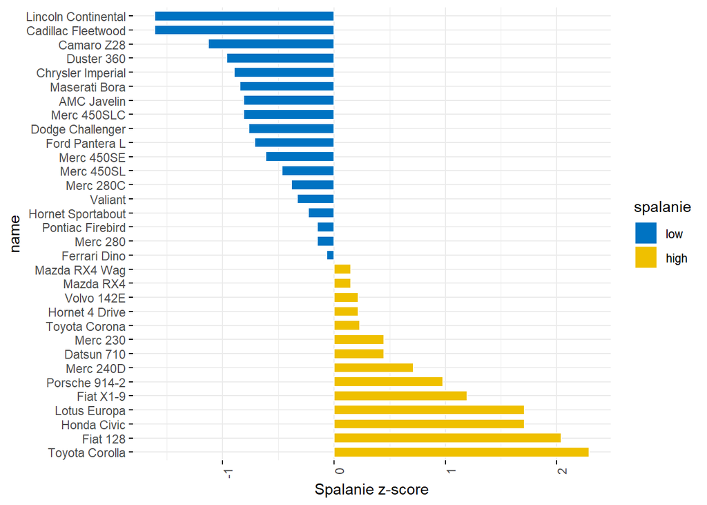

```r
ggbarplot(dfm, x = "name", y = "mpg_z",
          fill = "mpg_grp",
          color = "white",
          palette = "jco",
          sort.val = "desc",
          sort.by.groups = FALSE,
          x.text.angle = 90,
          ylab = "Spalanie z-score",
          legend.title = "spalanie",
          rotate = TRUE,
          ggtheme = theme_minimal()
          )
```

### Alternatywy dla wykresów słupkowych

#### Lizaki (ang. lollipop chart)

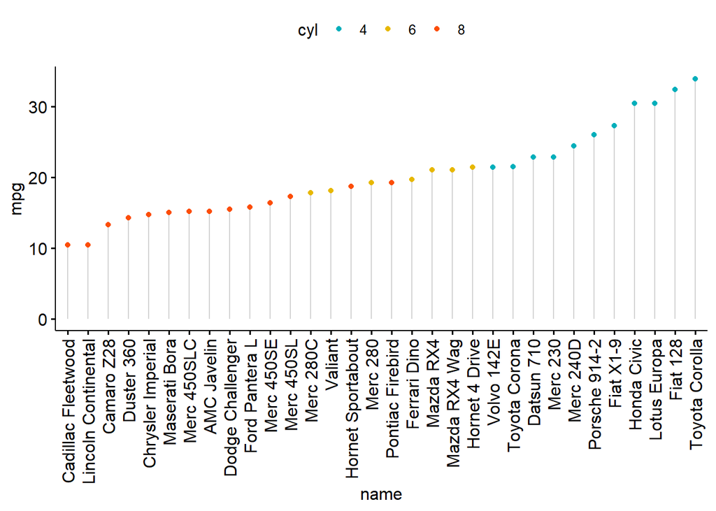

```r
ggdotchart(dfm, x = "name", y = "mpg",
           color = "cyl",                                # kolory zgodnie ze zmienną cyl
           palette = c("#00AFBB", "#E7B800", "#FC4E07"), # samodzielnie dobrane kolory
           sorting = "ascending",                        # rosnąco
           add = "segments",                             # dodanie segmentów od y = 0 do kropek
           ggtheme = theme_pubr()                        # temat ggplot2
           )
```

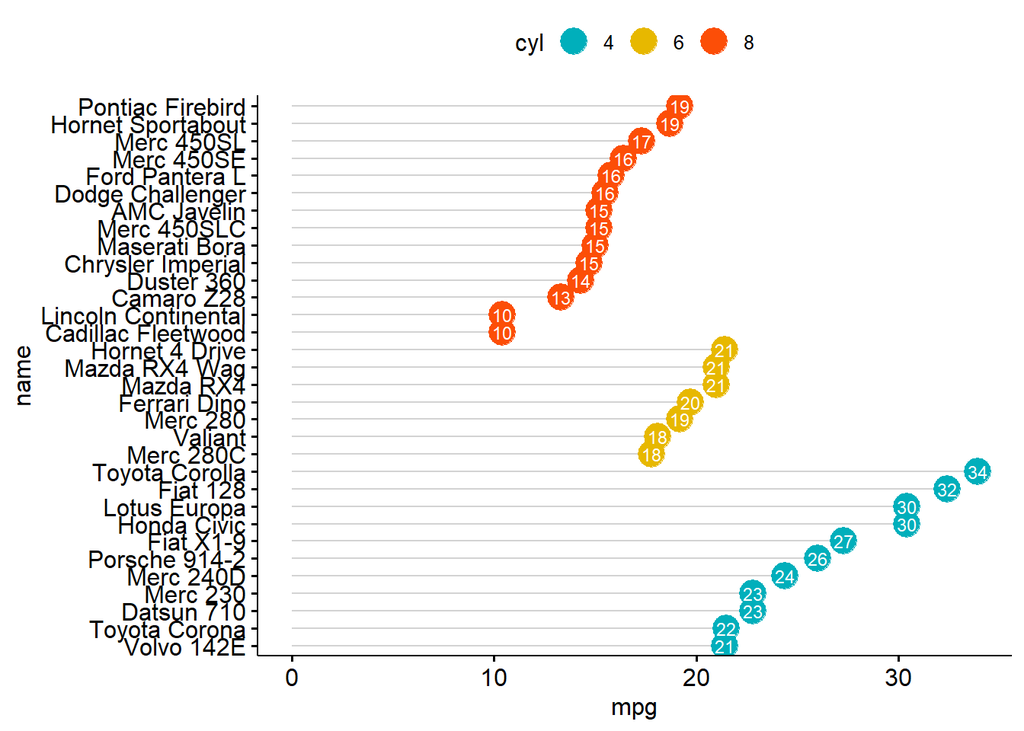

```r
ggdotchart(dfm, x = "name", y = "mpg",
           color = "cyl",
           palette = c("#00AFBB", "#E7B800", "#FC4E07"),
           sorting = "descending",                       # malejąco
           add = "segments",
           rotate = TRUE,                                # obróć
           group = "cyl",                                # posortuj grupami
           dot.size = 6,                                 # rozmiar punktu
           label = round(dfm$mpg),                        # dodanie wartości spalania jako etykiet
           font.label = list(color = "white", size = 9,
                             vjust = 0.5),               # parametry etykiet
           ggtheme = theme_pubr()
           )
```

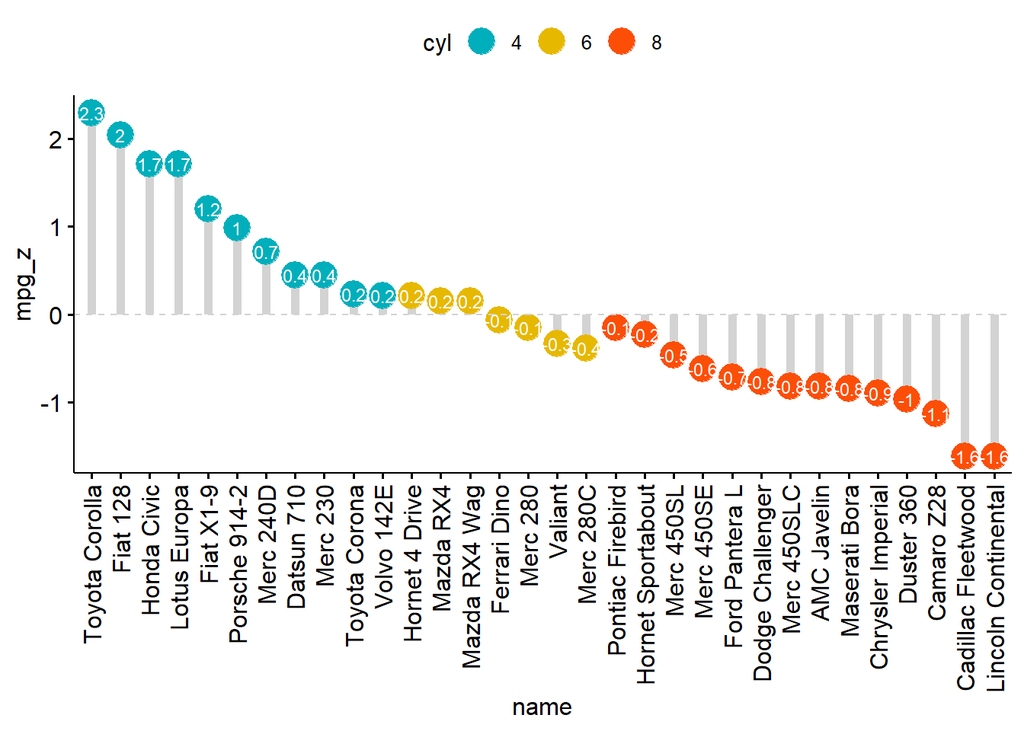

```r
ggdotchart(dfm, x = "name", y = "mpg_z",
           color = "cyl",
           palette = c("#00AFBB", "#E7B800", "#FC4E07"),
           sorting = "descending",
           add = "segments",
           add.params = list(color = "lightgray", size = 2), # zmiana koloru i rozmiaru w segmentach
           group = "cyl",                                # grupowanie zgodnie z wartościami cyl
           dot.size = 6,                                 # Large dot size
           label = round(dfm$mpg_z,1),
           font.label = list(color = "white", size = 9,
                             vjust = 0.5),
           ggtheme = theme_pubr()
           )+
  geom_hline(yintercept = 0, linetype = 2, color = "lightgray")
```